# A3: Incarceration Report

Mike Ramsay

2/25/2022

## Introduction

For this assignment, I am looking at incarceration statistics in the US during the past couple decades. I used a dataset from the Vera institute that contains lots of statistics on total populations, by state and county and their breakdowns by race and sex. It also contains information about the people incarcerated, like their race, whether they are a juvenile and why they are in jail. Some of the specific values that I explored are the states that have the largest proportions of their populations in jails as well as the total jail population changes over the past couple decades and what the jail population looks like when broken down by race. I chose these values because I know there are lots of issues and inequalities in our country surrounding race and incarceration, especially relating to the War on Drugs. I wanted to visualize this and show some supporting evidence for these issues.

## Charts

### Trends Over Time Chart

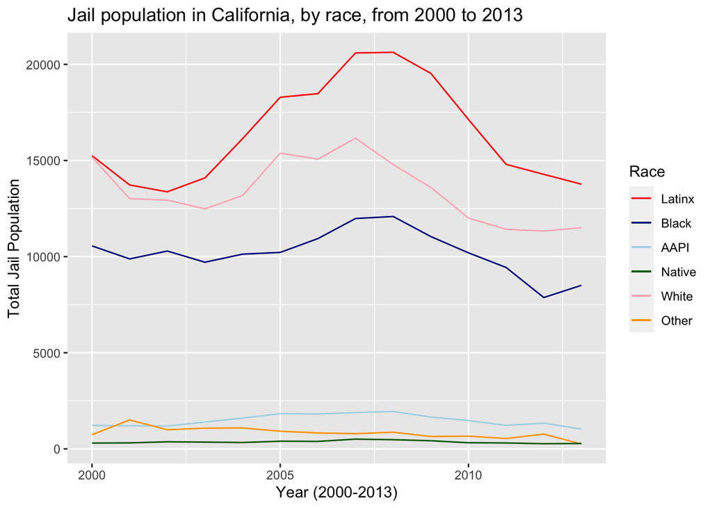

For this chart, I decided on measuring jail population in California from 2000 to 2013, broken down by race. I decided to include this chart because I was interested to see what the jail breakdown looks like in the most populus and one of the most diverse states. I also think that this chart shows some interesting trends, like how most listed races saw a spike around 2008. A notable take-away from this would be that this is roughly around the time of the 2008 recession, which could have played a factor in this peak of US jail population. Also, the Latinx population is clearly the largest in California jails, but this also is a state with one of the largest Latinx populations.

### Variable Comparison Chart

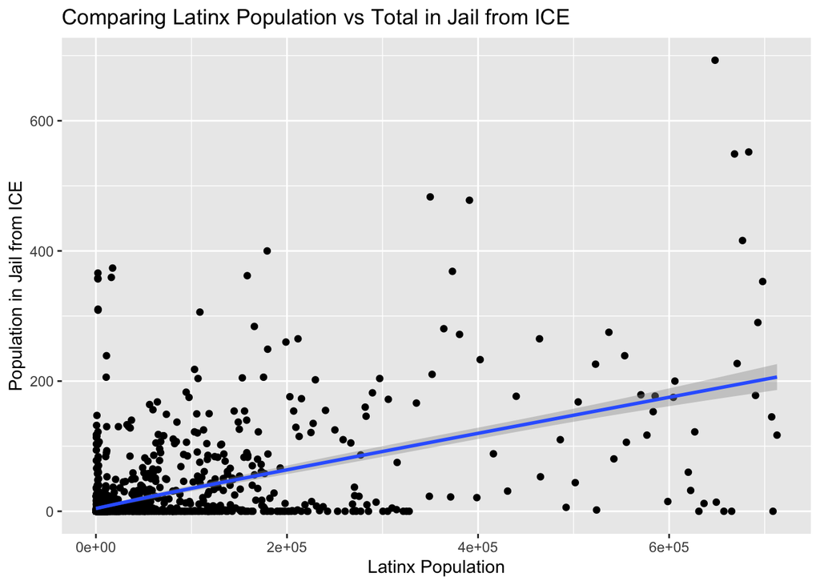

This is a chart comparing the Latinx population and the total population of people who are in jail from ICE. This is using the total Latinx population aged 15 to 64 because the Vera institute mentioned that this is the age group that is most likely to be jailed. It also shows a positive relationship, between counties with greater Latinx populations and more people being imprisoned from ICE. I included this chart because I think it shows some valuable information about some of the current issues with ICE’s role in our country and how some of these people of Latinx decent may be unfairly treated or targeted. One thing to add it that I only selected counties with a Latinx Population of less than one million. I did this to allow for more detail and make the graph look better, because these counties, most of which were New York, were way off in the upper right (as expected).

### Map

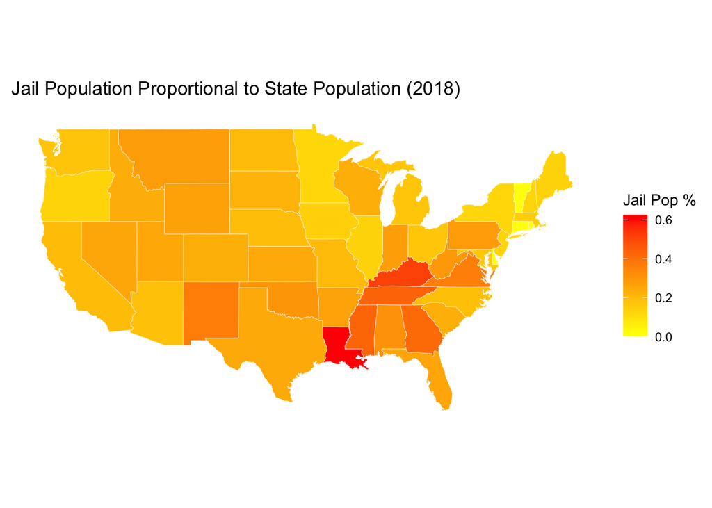

This is a map of the United States, displaying the jail populations, proportional to the state population in 2018. I included it because I was interested to see which states have the largest jail populations and I wanted to see if there are any “hotspots” or areas of higher concentrations. The states that are a deeper shade of red have larger jail populations, while the states with shades closer to yellow have smaller jail populations. The map shows that states in the southern portion of the United States, like Louisiana, Kentucky and Georgia, have a higher proportion of their populations in jails. Louisiana appears to have the highest concentration, with around 0.6% of its population in jail. It is also worth noting that these states generally have some of the largest populations of African Americans in the US, while also having the highest proportions of residents in jails.